# 05. Egg counts

Elliott Schmidt

2024-05-17

# Scenario

Within this chapter developmental plasticity was explored within *Acanthochromis polyacanthus* that were collected from two different regions (i.e., low-latitude, Cairns, and high-latitude, Mackay). Fish were held in common garden experiments at 28.5 C. Reproductive meterics are only relevant to parental fish. Understanding potential differences in reproduction within fish from low- and high-latitude populations will provide basis of where juveniles are starting from.

# Load packages

```r
library(tidyverse) # data manipulation
library(ggpubr) # figure arrangement
library(brms) # Bayesian models
library(StanHeaders)# needed to run Bayesian models
library(rstan) # needed to run Bayesian models
library(standist) # needs to be installed
library(bayesplot) # needed for MCMC diagnostics
library(DHARMa) # model validation
library(ggdist) # partial plots
library(tidybayes) # partial plots
library(broom.mixed) # model investigation
library(emmeans) # pairwise comparisons
library(rstanarm) # pairwise comparisons - need for emmeans
library(car)
```

# Set working directory

```r
knitr::opts_knit$set(root.dir=working.dir)
```

# Import data

Note that when making the datasheet, each clutch was designated an ‘experimental_number’ that is associated with which experiment(s) clutches were involved in, therefore when importing the data, we will filter data to give us only clutches that were used in the relevent ‘developmental plasticity experiment’. We are also dropping one clutch that was found only when individuals hatched, meaning we don’t know the clutch size, or hatching success

```r
clutch_data <- read_delim("import_files/clutch_data_2022_2023.txt",
    delim = "\t", escape_double = FALSE,
    trim_ws = TRUE) |>
  mutate(PROJECT_CODE = factor(PROJECT_CODE)) |>
  filter(PROJECT_CODE == "2"|
         PROJECT_CODE == "3"|
         PROJECT_CODE == "6"|
         PROJECT_CODE == "7") |>
  drop_na(EGG_COUNT)
```

We are left with 20 clutches; 12 from the Core region (from 11 unique pairs), and 8 from the leading region (from 5 unique pairs).

# Data manipulation

```r
clutch_data2 <- clutch_data |>
  mutate(CLUTCH_NUMBER = as.factor(CLUTCH_NUMBER),
         MALE = factor(MALE),
         FEMALE = factor(FEMALE),
         REGION = factor(REGION),
         POPULATION = factor(POPULATION),
         CLUTCH_ORDER = factor(CLUTCH_ORDER),
         DATE_OF_HATCH = as.Date(DATE_OF_HATCH, format = "%d/%m/%Y"),
         cMALE_MASS = scale(MALE_MASS, center=TRUE, scale=FALSE),
         cFEMALE_MASS = scale(FEMALE_MASS, center=TRUE, scale=FALSE),
         cEGG_COUNT = scale(EGG_COUNT, center=TRUE, scale=FALSE),
         FEMALE_MASS = coalesce(FEMALE_MASS, MALE_MASS))
```

# Exploratory data analysis

## Egg counts

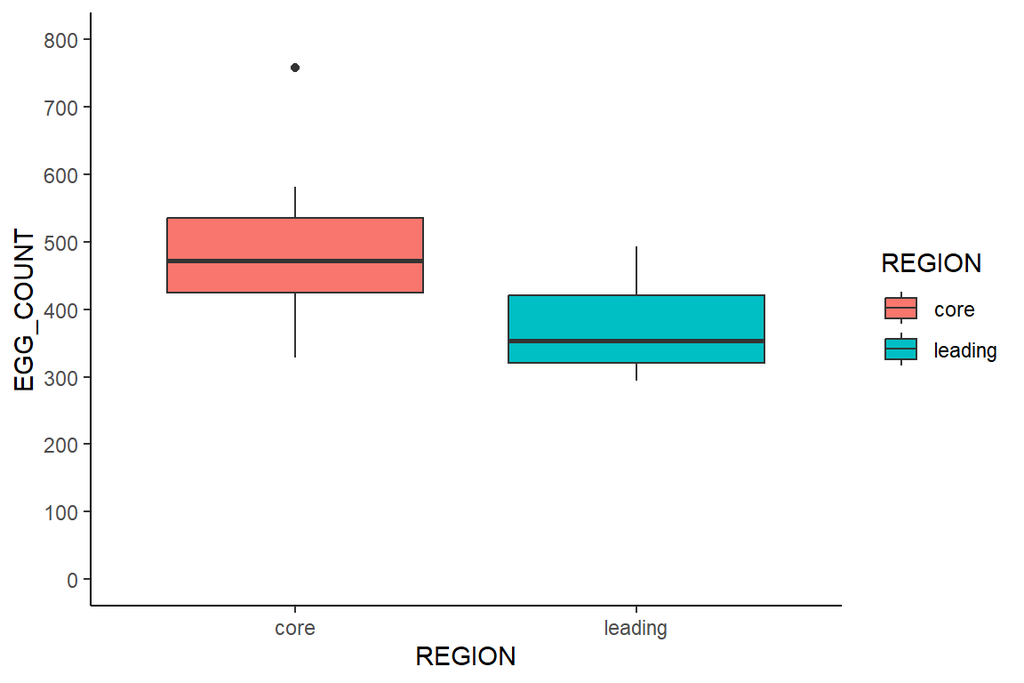

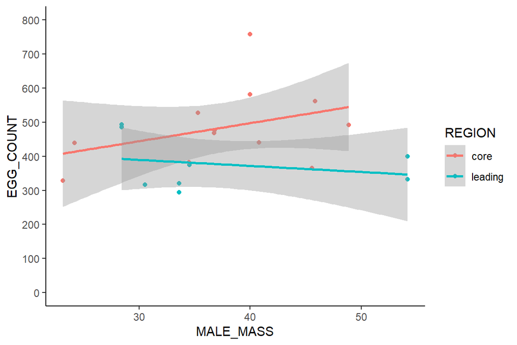

# Fit model [random factors]

Two different hypotheses will be tested to determine which fixed factors will make it into our final model. The first mode will look at fixed factors that are essential to the question being asked, the second tested hypothesis will see if temporal factors such as clutch order and days in treatment influence the outcome.

MALE_MASS and FEMALE_MASS are correlated and therefore only one is included within the model. FEMALE_MASS was included as it may be more influential when dealing with reproductive metrics. One Female did not have mass data collected due to a mortality event that would have made MASS data unreliable. For this female the male weight was used, because the both individuals were ~the same LENGTH, and LENGTH and MASS are highly correlated.

Hypothesis test will include:

0. Null model
1. EGG_COUNT ~ 1 + (1| FEMALE)
2. EGG_COUNT ~ 1 + (1| FEMALE) + (1| POPULATION)
3. EGG_COUNT ~ 1 + (1| FEMALE) + (1| CLUTCH_ORDER)
4. EGG_COUNT ~ 1 + (1| FEMALE) + (1| POPULATION) + (1| CLUTCH_ORDER)

## Prior investigation

```r
clutch_data2 |>
  group_by(REGION) |>
  summarise(mean(na.omit(EGG_COUNT)),
            sd(na.omit(EGG_COUNT)))
```

| REGION | mean(na.omit(EGG_COUNT)) | sd(na.omit(EGG_COUNT)) |
| --- | --- | --- |
| core | 485.0833 | 115.03158 |
| leading | 377.1250 | 76.81413 |

## Priors

```r
eggcount.priors <- prior(normal(425, 100), class="Intercept")
```

## Models

### Null

```r
f.null <- bf(EGG_COUNT ~ 1,
                     family=poisson())
```

```r
model.null <- brm(f.null,
              data = clutch_data2,
              prior = eggcount.priors,
              warmup = 500,
              iter = 5000,
              seed=123,
              cores=2,
              save_pars = save_pars(all=TRUE),
              sample_prior = "yes",
              chains = 2,
              thin = 5,
              control = list(adapt_delta=0.95))
saveRDS(model.null, file="./05.Reproductive_metrics_files/model_null_eggcount.RDS")
```

### Model1

```r
f.model1 <- bf(EGG_COUNT ~ 1 + (1| FEMALE),
                     family=poisson())
```

```r
model1 <- brm(f.model1,
              data = clutch_data2,
              prior = eggcount.priors,
              warmup = 500,
              iter = 5000,
              seed=123,
              cores=2,
              save_pars = save_pars(all=TRUE),
              sample_prior = "yes",
              chains = 2,
              thin = 5,
              control = list(adapt_delta=0.95))
saveRDS(model1 , file="./05.Reproductive_metrics_files/model1_eggcount.RDS")
```

### Model2

```r
f.model2 <- bf(EGG_COUNT ~ 1 + (1| FEMALE) + (1| POPULATION) ,
                     family=poisson())
```

```r
model2 <- brm(f.model2,
              data = clutch_data2,
              prior = eggcount.priors,
              warmup = 500,
              iter = 5000,
              seed=123,
              cores=2,
              save_pars = save_pars(all=TRUE),
              sample_prior = "yes",
              chains = 2,
              thin = 5,
              control = list(adapt_delta=0.95))
saveRDS(model2 , file="./05.Reproductive_metrics_files/model2_eggcount.RDS")
```

### Model 3

```r
f.model3 <- bf(EGG_COUNT ~ 1 + (1| FEMALE) + (1|CLUTCH_ORDER),
                     family=poisson())
```

```r
model3 <- brm(f.model3,
              data = clutch_data2,
              prior = eggcount.priors,
              warmup = 500,
              iter = 5000,
              seed=123,
              cores=2,
              save_pars = save_pars(all=TRUE),
              sample_prior = "yes",
              chains = 2,
              thin = 5,
              control = list(adapt_delta=0.95))
saveRDS(model3 , file="./05.Reproductive_metrics_files/model3_eggcount.RDS")
```

### Model 4

```r
f.model4 <- bf(EGG_COUNT ~ 1 + (1| FEMALE) + (1|POPULATION) + (1|CLUTCH_ORDER),
                     family=poisson())
```

```r
model4 <- brm(f.model4,
              data = clutch_data2,
              prior = eggcount.priors,
              warmup = 500,
              iter = 5000,
              seed=123,
              cores=2,
              save_pars = save_pars(all=TRUE),
              sample_prior = "yes",
              chains = 2,
              thin = 5,
              control = list(adapt_delta=0.95))
saveRDS(model4 , file="./05.Reproductive_metrics_files/model4_eggcount.RDS")
```

### LOO

```r
LOO(model.null, model1, model2, model3, model4)
```

```
## Output of model 'model.null':
##
## Computed from 1800 by 20 log-likelihood matrix.
##
##          Estimate    SE
## elpd_loo   -355.2  97.7
## p_loo        27.7  10.8
## looic       710.3 195.4
## ------
## MCSE of elpd_loo is NA.
## MCSE and ESS estimates assume MCMC draws (r_eff in [0.9, 1.0]).
##
## Pareto k diagnostic values:
##                           Count Pct.    Min. ESS
## (-Inf, 0.69]   (good)     19    95.0%   126
##    (0.69, 1]   (bad)       0     0.0%   <NA>
##     (1, Inf)   (very bad)  1     5.0%   <NA>
## See help('pareto-k-diagnostic') for details.
##
## Output of model 'model1':
##
## Computed from 1800 by 20 log-likelihood matrix.
##
##          Estimate   SE
## elpd_loo   -120.4 12.7
## p_loo        25.4  7.2
## looic       240.8 25.4
## ------
## MCSE of elpd_loo is NA.
## MCSE and ESS estimates assume MCMC draws (r_eff in [0.8, 1.1]).
##
## Pareto k diagnostic values:
##                           Count Pct.    Min. ESS
## (-Inf, 0.69]   (good)      5    25.0%   184
##    (0.69, 1]   (bad)      12    60.0%   <NA>
##     (1, Inf)   (very bad)  3    15.0%   <NA>
## See help('pareto-k-diagnostic') for details.
##
## Output of model 'model2':
##
```

[output cut: 47 more lines]

```
##
## Pareto k diagnostic values:
##                           Count Pct.    Min. ESS
## (-Inf, 0.69]   (good)      5    25.0%   189
##    (0.69, 1]   (bad)      10    50.0%   <NA>
##     (1, Inf)   (very bad)  5    25.0%   <NA>
## See help('pareto-k-diagnostic') for details.
##
## Model comparisons:
##            elpd_diff se_diff
## model4        0.0       0.0
## model1       -1.1       8.9
## model3       -1.4       1.8
## model2       -4.8      10.1
## model.null -235.8      94.5
```

# Fit model [fixed factors]

Before testing models a quick analysis of collinearity will be tested due to the likely hood of CLUTCH_ORDER and DAYS_IN_TREATMENT being correlated to each other

```r
mcol <- lm(EGG_COUNT ~ 1 +
                       REGION + CLUTCH_ORDER +
                       scale(DAYS_IN_TREATMENT, center=TRUE, scale=TRUE) +
                       scale(MALE_MASS, center=TRUE, scale=TRUE),
           family=gaussian(),
           data=clutch_data2); vif(mcol)
```

```
##                                                           GVIF Df
## REGION                                                3.868306  1
## CLUTCH_ORDER                                          6.416703  3
## scale(DAYS_IN_TREATMENT, center = TRUE, scale = TRUE) 3.276752  1
## scale(MALE_MASS, center = TRUE, scale = TRUE)         1.387576  1
##                                                       GVIF^(1/(2*Df))
## REGION                                                       1.966801
## CLUTCH_ORDER                                                 1.363176
## scale(DAYS_IN_TREATMENT, center = TRUE, scale = TRUE)        1.810180
## scale(MALE_MASS, center = TRUE, scale = TRUE)                1.177954
```

As a result CLUTCH_ORDER will be removed from the model

Two different hypotheses will be tested:

** Notice the interaction term in the second model

## Priors investigation

```r
clutch_data2 |>
  group_by(REGION) |>
  summarise(mean(na.omit(EGG_COUNT)),
            sd(na.omit(EGG_COUNT)))
```

| REGION | mean(na.omit(EGG_COUNT)) | sd(na.omit(EGG_COUNT)) |
| --- | --- | --- |
| core | 485.0833 | 115.03158 |
| leading | 377.1250 | 76.81413 |

## Priors

```r
eggcount.priors <- prior(normal(425, 100), class="Intercept") +
  prior(normal(0, 40), class="b")
```

## Models

### Model1.1

```r
f.model1.1 <- bf(EGG_COUNT ~ 1 + REGION +
                       scale(FEMALE_MASS, center=TRUE, scale=TRUE) +
                       scale(DAYS_IN_TREATMENT, center=TRUE, scale=TRUE) +
                       (1| FEMALE),
                       family=poisson())

model1.1 <- brm(f.model1.1,
              data = clutch_data2,
              prior = eggcount.priors,
              warmup = 500,
              iter = 5000,
              seed=123,
              cores=2,
              save_pars = save_pars(all=TRUE),
              sample_prior = "yes",
              chains = 2,
              thin = 5,
              control = list(adapt_delta=0.99))
saveRDS(model1.1, file="./05.Reproductive_metrics_files/model1.1_eggcount.RDS")
```

#### Model performance

```r
stan_trace(model1.1$fit)
```

```
## 'pars' not specified. Showing first 10 parameters by default.
```

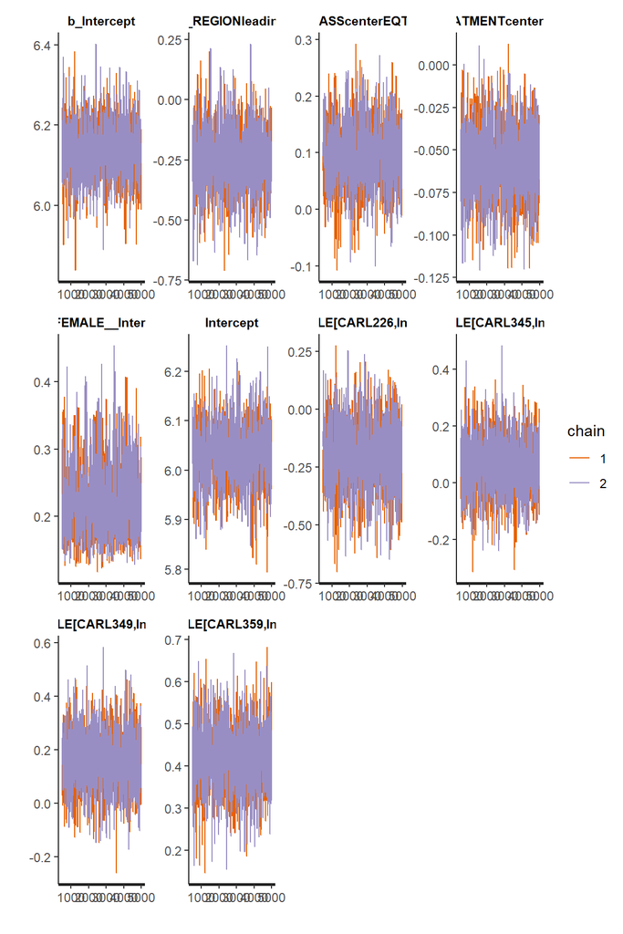

```r
stan_ac(model1.1$fit)
```

```
## 'pars' not specified. Showing first 10 parameters by default.
```

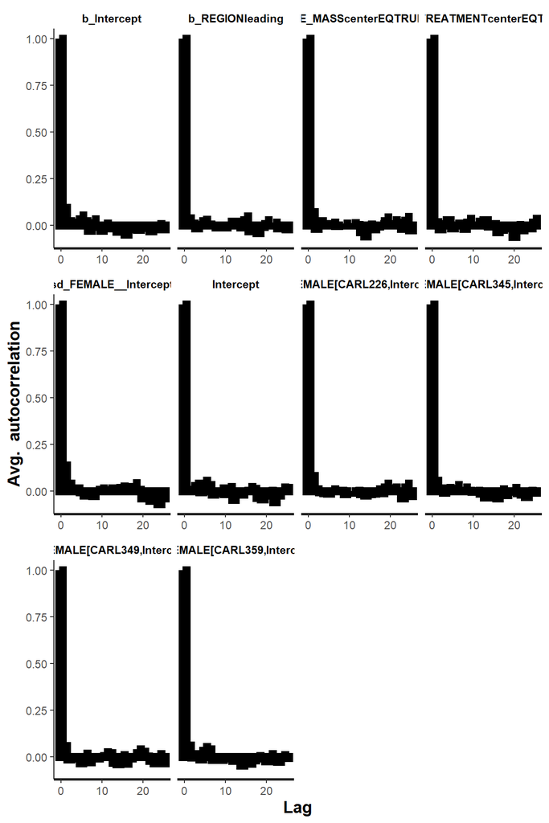

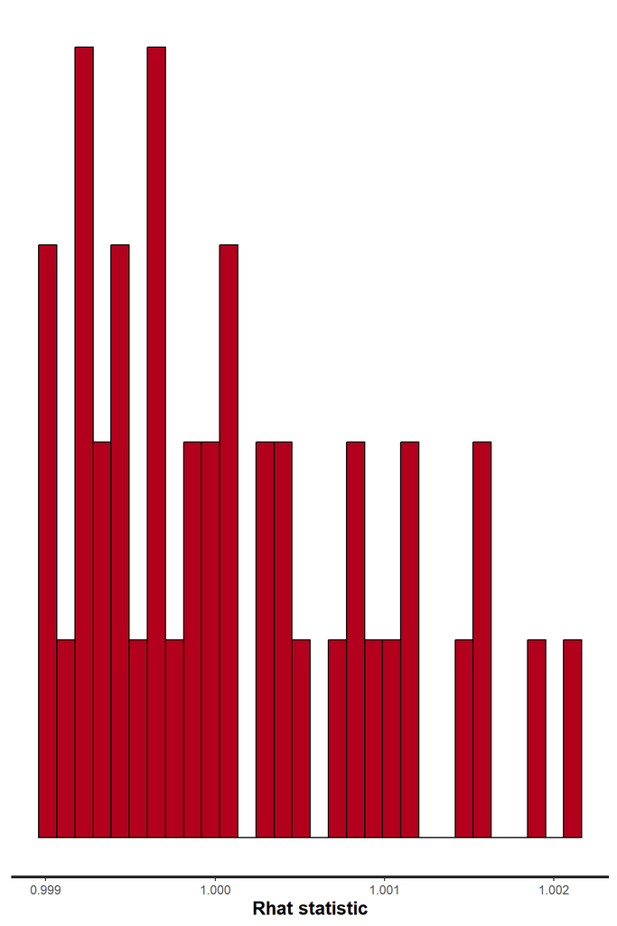

```r
stan_rhat(model1.1$fit)
```

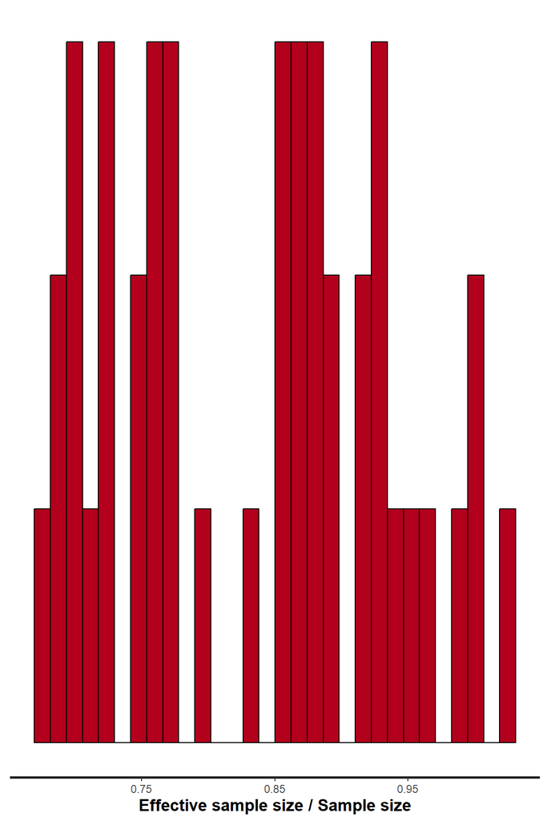

```r
stan_ess(model1.1$fit)
```

```r
stan_dens(model1.1$fit, separate_chains = TRUE)
```

```
## 'pars' not specified. Showing first 10 parameters by default.
```

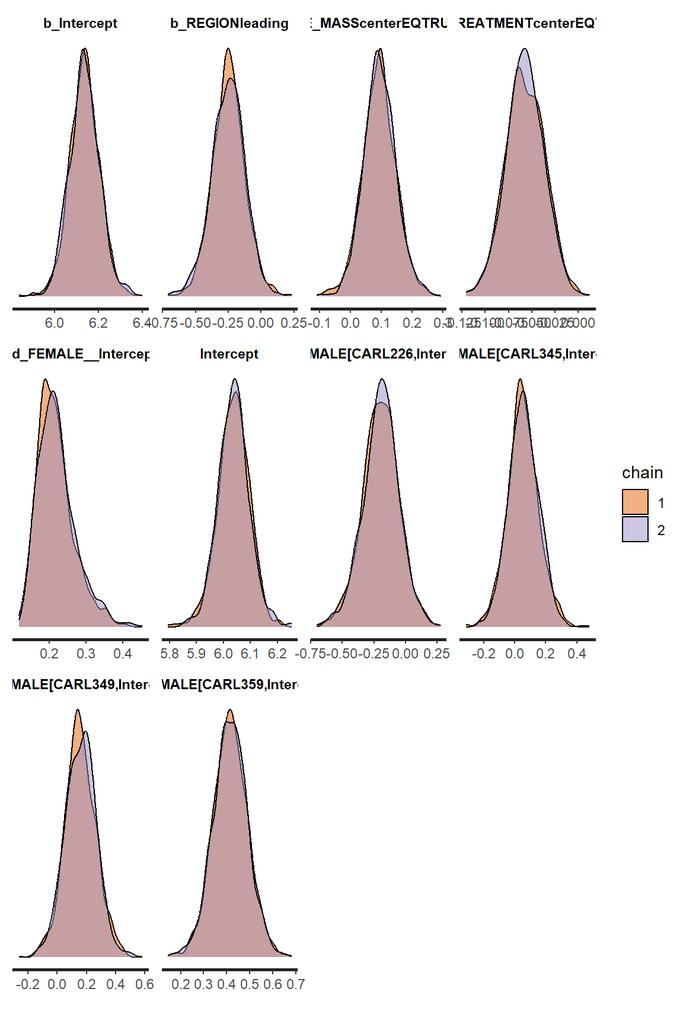

#### Model diagnositics

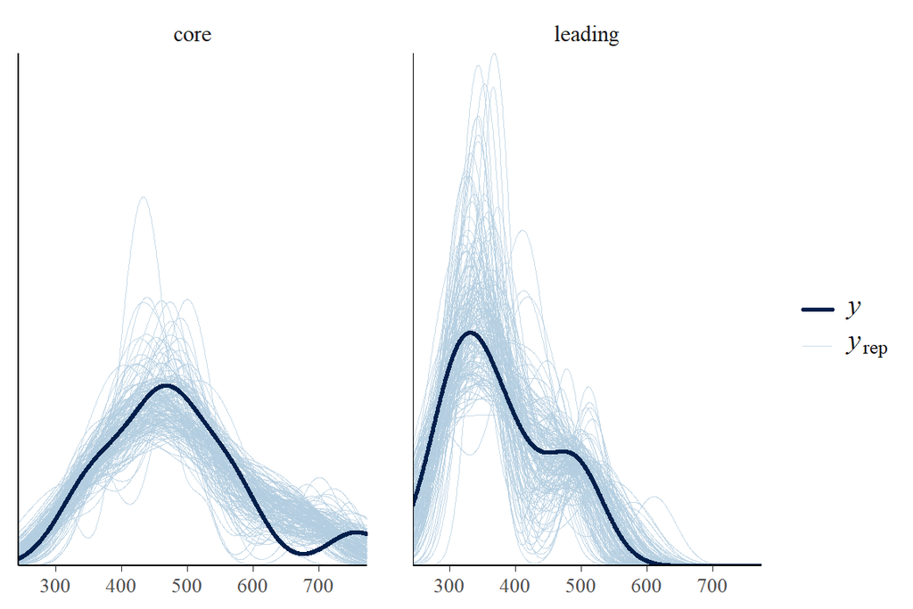

```r
#--- distribution check ---#
pp_check(model1.1, type = 'dens_overlay_grouped', ndraws=150, group="REGION")
```

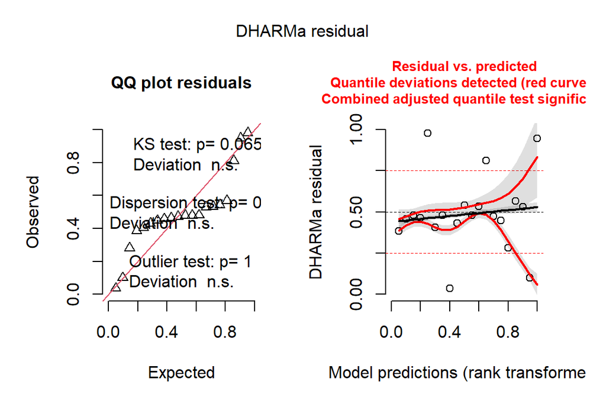

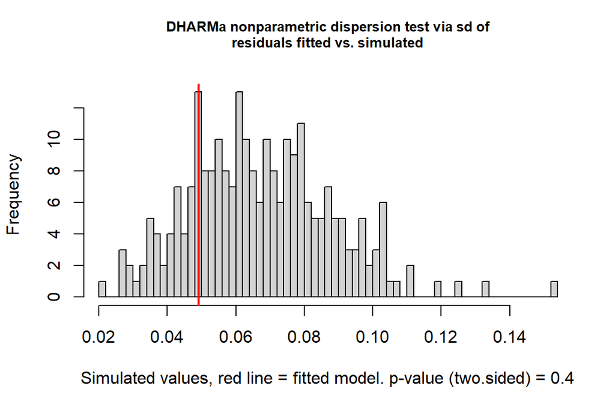

```
##
##  DHARMa nonparametric dispersion test via sd of residuals fitted vs.
##  simulated
##
## data:  simulationOutput
## dispersion = 0.72969, p-value = 0.4
## alternative hypothesis: two.sided
```

```r
preds <- posterior_predict(model1.1, ndraws=250, summary=FALSE)
model1.1_resids <- createDHARMa(simulatedResponse = t(preds),
                              observedResponse = na.omit(clutch_data2$EGG_COUNT),
                              fittedPredictedResponse = apply(preds, 2, mean),
                              integerResponse = 'student')
plot(model1.1_resids) ; testDispersion(model1.1_resids)
```

### Model 1.2

```r
f.model1.2 <- bf(EGG_COUNT ~ 1 + REGION*scale(FEMALE_MASS, center=TRUE, scale=TRUE) +
                       scale(DAYS_IN_TREATMENT, center=TRUE, scale=TRUE) +
                       (1| FEMALE),
                     family=poisson())

model1.2 <- brm(f.model1.2,
              data = clutch_data2,
              prior = eggcount.priors,
              warmup = 500,
              iter = 5000,
              seed=123,
              cores=2,
              save_pars = save_pars(all=TRUE),
              sample_prior = "yes",
              chains = 2,
              thin = 5,
              control = list(adapt_delta=0.99))
saveRDS(model1.2, file="./05.Reproductive_metrics_files/model1.2_eggcount.RDS")
```

#### Model performance

```r
stan_trace(model1.2$fit)
```

```
## 'pars' not specified. Showing first 10 parameters by default.
```

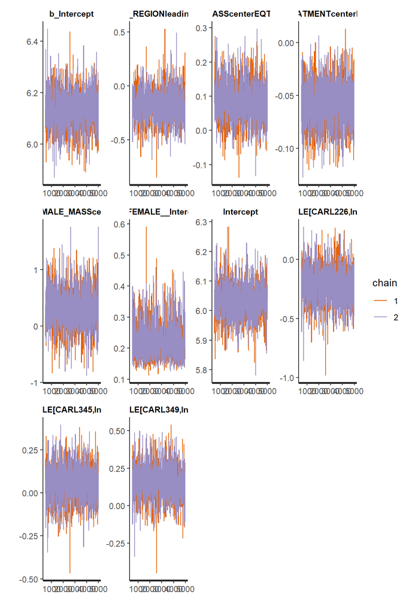

```r
stan_ac(model1.2$fit)
```

```
## 'pars' not specified. Showing first 10 parameters by default.
```

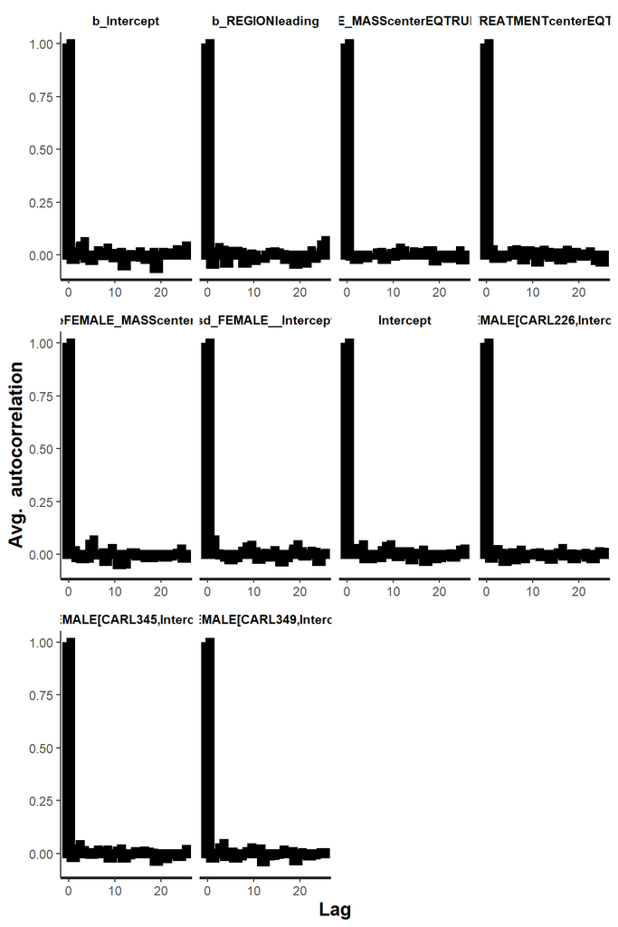

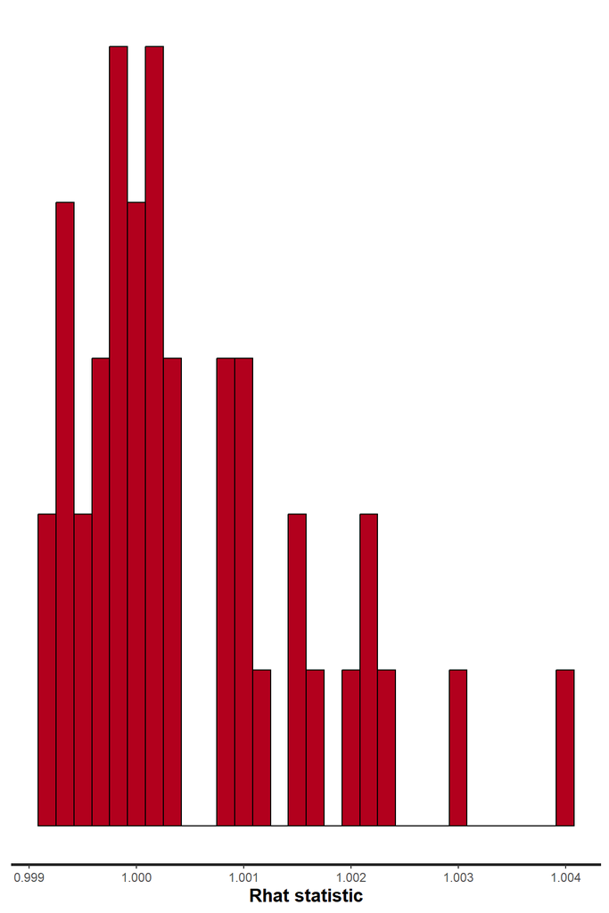

```r
stan_rhat(model1.2$fit)
```

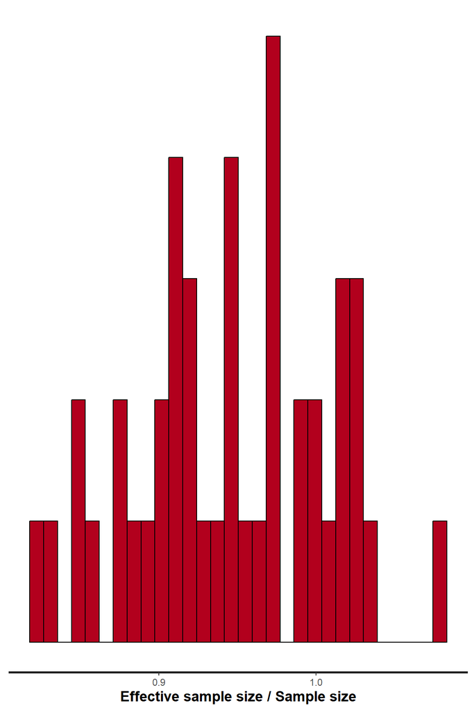

```r
stan_ess(model1.2$fit)
```

```r
stan_dens(model1.2$fit, separate_chains = TRUE)
```

```
## 'pars' not specified. Showing first 10 parameters by default.
```

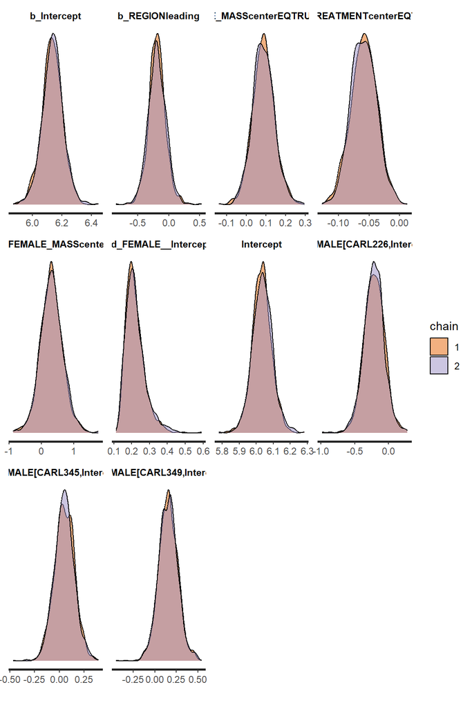

#### Model diagnositics

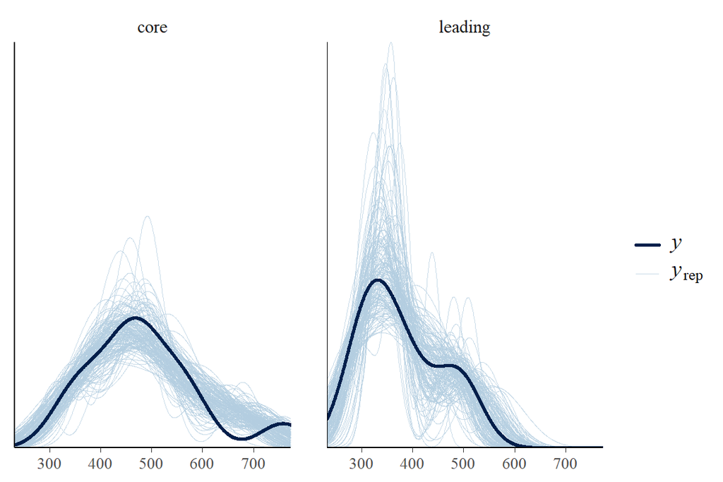

```r
#--- distribution check ---#
pp_check(model1.2, type = 'dens_overlay_grouped', ndraws=150, group="REGION")
```

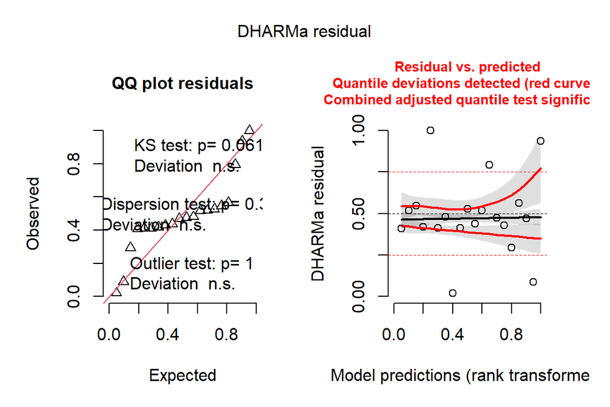

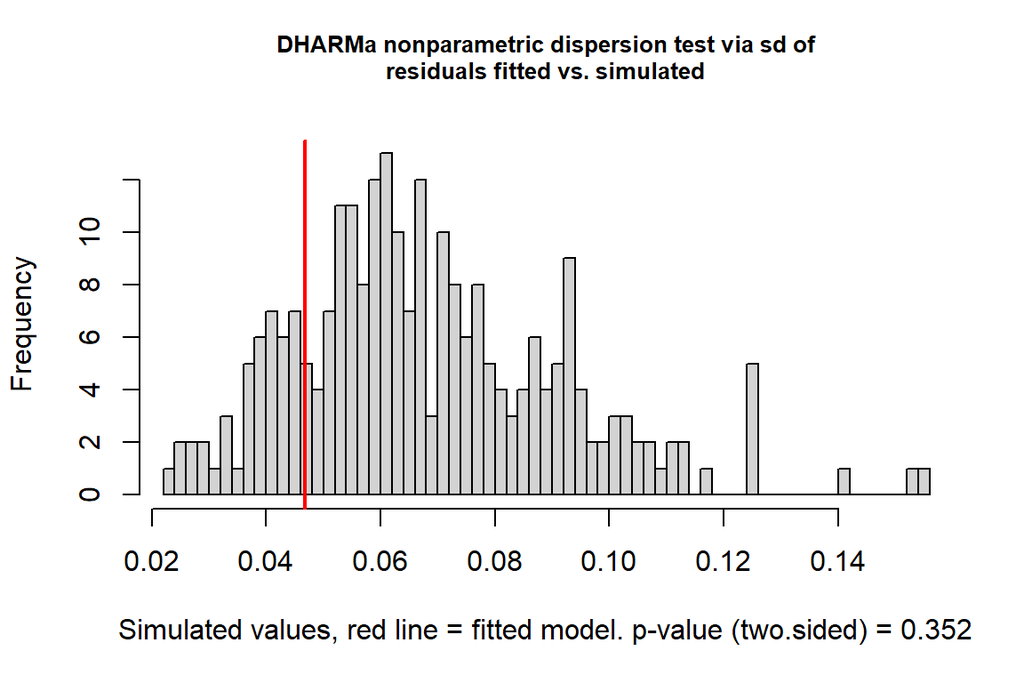

```
##
##  DHARMa nonparametric dispersion test via sd of residuals fitted vs.
##  simulated
##
## data:  simulationOutput
## dispersion = 0.68654, p-value = 0.352
## alternative hypothesis: two.sided
```

```r
preds <- posterior_predict(model1.2, ndraws=250, summary=FALSE)
model1.2_resids <- createDHARMa(simulatedResponse = t(preds),
                              observedResponse = na.omit(clutch_data2$EGG_COUNT),
                              fittedPredictedResponse = apply(preds, 2, mean),
                              integerResponse = 'student')
plot(model1.2_resids) ; testDispersion(model1.2_resids)
```

### LOO

```r
LOO(model1.1, model1.2)
```

```
## Output of model 'model1.1':
##
## Computed from 1800 by 20 log-likelihood matrix.
##
##          Estimate   SE
## elpd_loo   -117.7  9.1
## p_loo        26.0  6.2
## looic       235.4 18.2
## ------
## MCSE of elpd_loo is NA.
## MCSE and ESS estimates assume MCMC draws (r_eff in [0.8, 1.0]).
##
## Pareto k diagnostic values:
##                           Count Pct.    Min. ESS
## (-Inf, 0.69]   (good)      5    25.0%   118
##    (0.69, 1]   (bad)      11    55.0%   <NA>
##     (1, Inf)   (very bad)  4    20.0%   <NA>
## See help('pareto-k-diagnostic') for details.
##
## Output of model 'model1.2':
##
## Computed from 1800 by 20 log-likelihood matrix.
##
##          Estimate   SE
## elpd_loo   -118.7  9.1
## p_loo        27.1  6.2
## looic       237.4 18.1
## ------
## MCSE of elpd_loo is NA.
## MCSE and ESS estimates assume MCMC draws (r_eff in [0.8, 1.0]).
##
## Pareto k diagnostic values:
##                           Count Pct.    Min. ESS
## (-Inf, 0.69]   (good)     6     30.0%   170
##    (0.69, 1]   (bad)      8     40.0%   <NA>
##     (1, Inf)   (very bad) 6     30.0%   <NA>
## See help('pareto-k-diagnostic') for details.
##
## Model comparisons:
##          elpd_diff se_diff
## model1.1  0.0       0.0
## model1.2 -1.0       1.1
```

# Partial effects plots

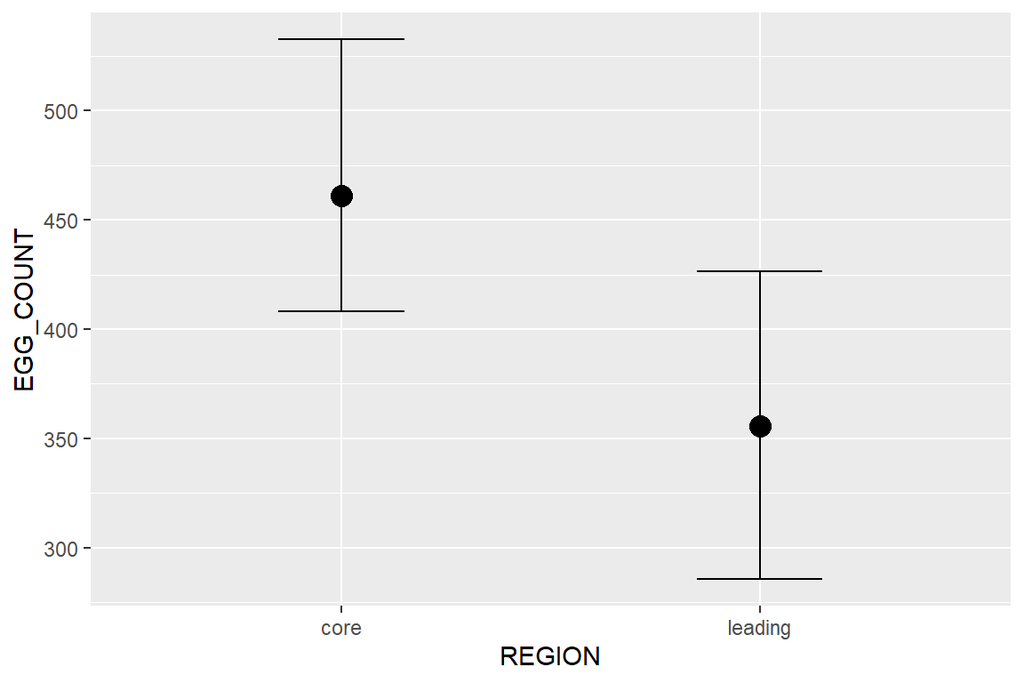

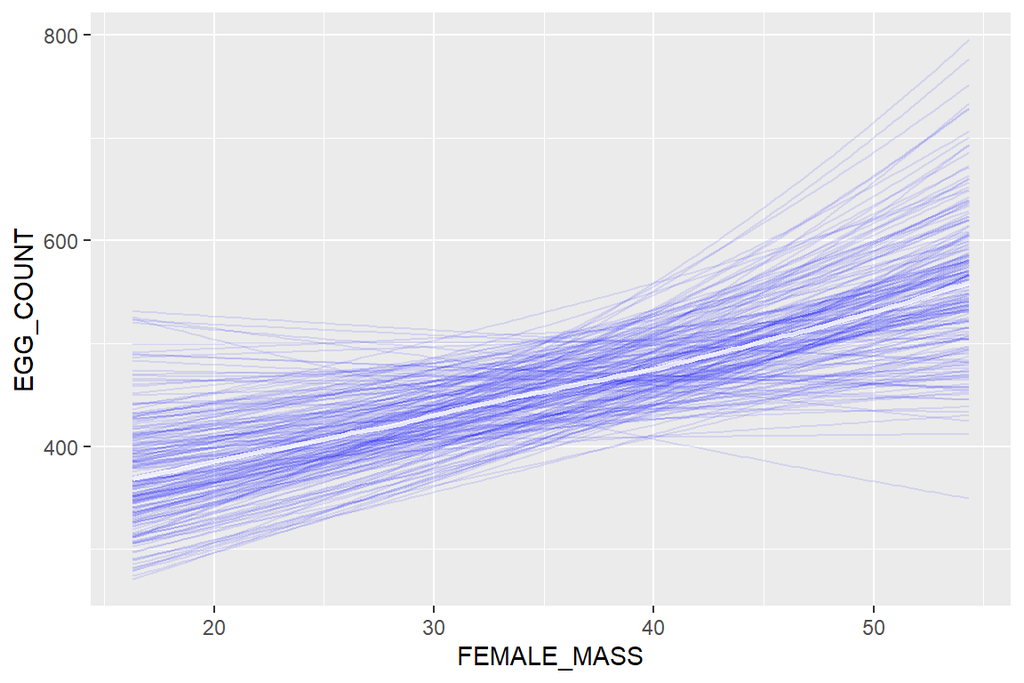

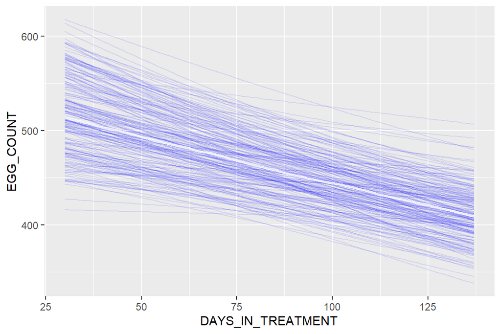

```r
model1.1 |>
  conditional_effects(spaghetti = TRUE, ndraws=200)
```

# Model investigation

## summary

```r
summary(model1.1)
```

```
##  Family: poisson
##   Links: mu = log
## Formula: EGG_COUNT ~ 1 + REGION + scale(FEMALE_MASS, center = TRUE, scale = TRUE) + scale(DAYS_IN_TREATMENT, center = TRUE, scale = TRUE) + (1 | FEMALE)
##    Data: clutch_data2 (Number of observations: 20)
##   Draws: 2 chains, each with iter = 5000; warmup = 500; thin = 5;
##          total post-warmup draws = 1800
##
## Group-Level Effects:
## ~FEMALE (Number of levels: 16)
##               Estimate Est.Error l-95% CI u-95% CI Rhat Bulk_ESS Tail_ESS
## sd(Intercept)     0.22      0.05     0.14     0.35 1.00     1304     1512
##
## Population-Level Effects:
##                                               Estimate Est.Error l-95% CI
## Intercept                                         6.14      0.07     6.00
## REGIONleading                                    -0.25      0.13    -0.51
## scaleFEMALE_MASScenterEQTRUEscaleEQTRUE           0.09      0.05    -0.01
## scaleDAYS_IN_TREATMENTcenterEQTRUEscaleEQTRUE    -0.06      0.02    -0.10
##                                               u-95% CI Rhat Bulk_ESS Tail_ESS
## Intercept                                         6.27 1.00     1380     1515
## REGIONleading                                    -0.01 1.00     1672     1505
## scaleFEMALE_MASScenterEQTRUEscaleEQTRUE           0.20 1.00     1496     1463
## scaleDAYS_IN_TREATMENTcenterEQTRUEscaleEQTRUE    -0.02 1.00     1635     1547
##
## Draws were sampled using sampling(NUTS). For each parameter, Bulk_ESS
## and Tail_ESS are effective sample size measures, and Rhat is the potential
## scale reduction factor on split chains (at convergence, Rhat = 1).
```

## R2

```r
model1.1 |> bayes_R2(summary = FALSE) |> median_hdci()
```

| y | ymin | ymax | .width | .point | .interval |
| --- | --- | --- | --- | --- | --- |
| 0.9292474 | 0.897941 | 0.9517172 | 0.95 | median | hdci |

## tidyMCMC

```r
tidyMCMC(model1.1, estimate.method='median', conf.int=TRUE, conf.method='HPDinterval')
```

| term | estimate | std.error | conf.low | conf.high |
| --- | --- | --- | --- | --- |
| b_Intercept | 6.13547725 | 0.069080703 | 6.002135093 | 6.26833751 |
| b_REGIONleading | -0.24870492 | 0.126302115 | -0.514415413 | -0.01845785 |
| b_scaleFEMALE_MASScenterEQTRUEscaleEQTRUE | 0.09343758 | 0.053555536 | -0.006130531 | 0.20705726 |
| b_scaleDAYS_IN_TREATMENTcenterEQTRUEscaleEQTRUE | -0.05729664 | 0.020630800 | -0.097163405 | -0.01764415 |
| sd_FEMALE__Intercept | 0.21224379 | 0.050317615 | 0.130537193 | 0.32050167 |
| Intercept | 6.03866963 | 0.058677662 | 5.926367526 | 6.15636256 |
| r_FEMALE[CARL226,Intercept] | -0.19518044 | 0.143650631 | -0.510326215 | 0.06696639 |
| r_FEMALE[CARL345,Intercept] | 0.05218896 | 0.099044936 | -0.150077206 | 0.23835730 |
| r_FEMALE[CARL349,Intercept] | 0.15863173 | 0.106714368 | -0.065325137 | 0.36099169 |
| r_FEMALE[CARL359,Intercept] | 0.41596201 | 0.075430178 | 0.268174320 | 0.56600670 |

[output cut: 32 more lines]

## gather draws

```r
#model1.re.wo |> get_variables()
model1.1 |> gather_draws(`b_.*|sigma`, regex =TRUE) |>
  median_hdci()
```

| .variable | .value | .lower | .upper | .width | .point | .interval |
| --- | --- | --- | --- | --- | --- | --- |
| b_Intercept | 6.13547725 | 6.00213509 | 6.268337513 | 0.95 | median | hdci |
| b_REGIONleading | -0.24870492 | -0.50136399 | -0.002957329 | 0.95 | median | hdci |
| b_scaleDAYS_IN_TREATMENTcenterEQTRUEscaleEQTRUE | -0.05729664 | -0.09544306 | -0.015285725 | 0.95 | median | hdci |
| b_scaleFEMALE_MASScenterEQTRUEscaleEQTRUE | 0.09343758 | -0.00669819 | 0.206491214 | 0.95 | median | hdci |

## bayesplot

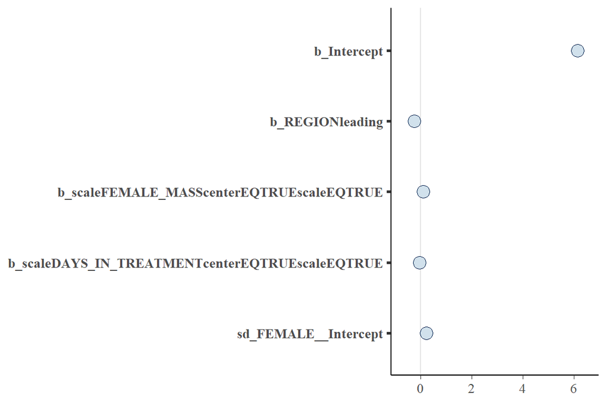

```r
model1.1 |> mcmc_plot(type='intervals')
```

## emmeans - pariwise

```r
model1.1 |> emmeans(pairwise ~ REGION, type="response") |> summary()
```

```
## $emmeans
##  REGION  rate lower.HPD upper.HPD
##  core     462       404       528
##  leading  362       292       445
##
## Point estimate displayed: median
## Results are back-transformed from the log scale
## HPD interval probability: 0.95
##
## $contrasts
##  contrast       ratio lower.HPD upper.HPD
##  core / leading  1.28     0.992      1.64
##
## Point estimate displayed: median
## Results are back-transformed from the log scale
## HPD interval probability: 0.95
```

## probabilities

```r
mtsqst <- model1.1 |> emmeans(pairwise ~ REGION)
mtsqrt1 <- mtsqst$contrasts |> gather_emmeans_draws()
mtsqrt1 %>% group_by(contrast) %>% dplyr::summarise(Prob = sum(.value>0)/n())
```

| contrast | Prob |
| --- | --- |
| core - leading | 0.9772222 |

# summary figure

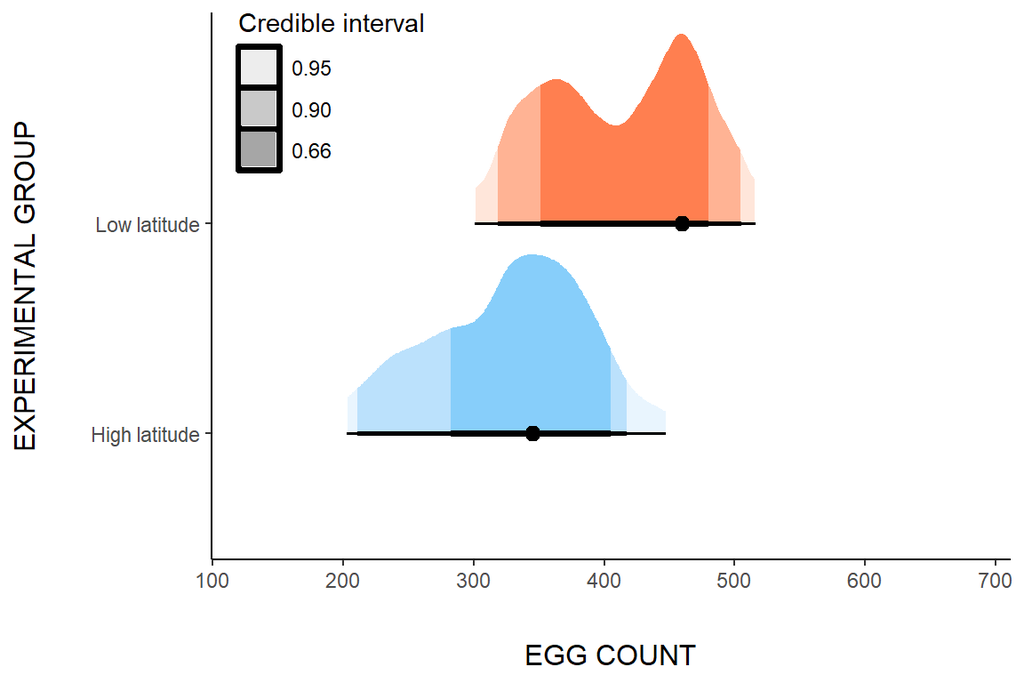

```r
var <- get_variables(model1.1)
var1 <- get_variables(model1.1)[c(1:2)]

int_draws_spread <- model1.1 |> spread_draws(!!!syms(var1))

int_draws_spread2 <- int_draws_spread |>
  gather_draws(b_Intercept, b_REGIONleading) |>
  left_join(int_draws_spread, by = c(".chain",".iteration",".draw"))


int_draws <- int_draws_spread2 |>
  mutate(RCore = case_when(`.variable` == 'b_Intercept' ~
                             `.value`,
                           `.variable` != 'b_Intercept' ~
                             `.value` + b_Intercept),

         RLeading = case_when(`.variable` == 'b_Intercept' ~
                           `.value` + b_REGIONleading,
                         `.variable` == 'b_REGIONleading' ~
                           `.value` + b_Intercept + `b_REGIONleading`))

int_draws_plotting <- int_draws |>
  pivot_longer(cols = starts_with("R"),
               names_to = "REGION",
               values_to = "EGG_COUNT") |>
  transmute(LATITUDE = case_when(`.variable` == "b_Intercept" ~ "Low latitude",
                                 `.variable` == "b_REGIONleading" ~ "High latitude"),
            EGG_COUNT = EGG_COUNT,
            LATITUDE_B = LATITUDE,
            chain = `.chain`,
            iteration = `.iteration`,
            draw_n = `.draw`) |>
  mutate(rEGG_COUNT = exp(EGG_COUNT))

eggcount.plot <- int_draws_plotting |>
  ggplot(aes(x=LATITUDE, y=rEGG_COUNT)) +
  #geom_hline(yintercept = 0, linetype="dashed", linewidth=1, color="grey58", alpha=0.8) +
  stat_halfeye(aes(fill = LATITUDE, fill_ramp = after_stat(level)),
               point_interval = mode_hdci,
               .width = c(.66, .90, .95)) +
  scale_fill_ramp_discrete(na.translate=FALSE,
                           labels =c("0.95","0.90","0.66"),
                           name = "Credible interval") +
  scale_fill_manual(values = c("lightskyblue","coral"))+
  #scale_y_continuous(limits=c(0,2), breaks = seq(0,2, .5))+
  ylab("EGG COUNT") + xlab("EXPERIMENTAL GROUP") +
  scale_x_discrete(labels = c("Low latitude" = paste0("Low latitude"),
                              "High latitude" = paste0("High latitude"))) +
  #annotate("text", x=6.8,y=1.4, label = paste0(round(mean(growth3$MASS), 2)," (mm)"), color="grey58") +
  coord_flip() +
  theme_classic() +
  guides(fill = "none") +
  theme(legend.position = c(.15,.86),
        axis.title.y = element_text(margin = margin(r =0.3, unit = "in"), size = 12),
        axis.title.x = element_text(margin = margin(t = 0.3, unit="in"), size =12),
        legend.key = element_rect(color="black", size=1.25),
        legend.background = element_rect(fill = alpha("blue", 0))); eggcount.plot
```

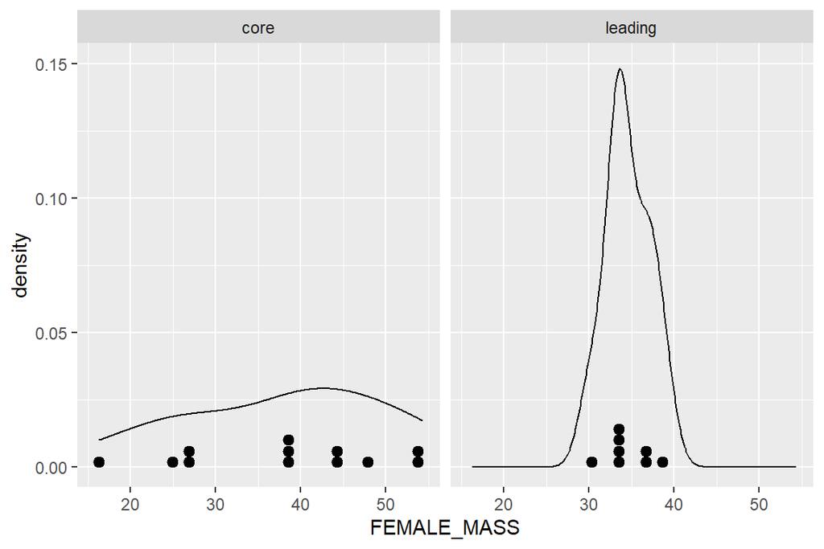

```r
ggplot(clutch_data2, aes(FEMALE_MASS))+
  geom_dotplot() +
  geom_density() +
  facet_wrap(~REGION) +
  ylim(0,0.15)
```